# Homework#2 - Die experiment and Music Shuffle

Riyesh Nath

2025-09-12

**GROUP MEMBERS:** Aqeel Choudhury, Heidy Collado and Ege Yanik

## DIE EXPERIMENT (PART 1)

### SUMMARY:

In this experiment, we will try to prove the fairness of a die that was heated in an oven for 20 minutes. We want to claim that this die is not fair.

• We first have null hypothesis to make claim that our dice is fair and we try to prove this claim wrong.

- **Null Hypothesis**: The die is fair. The probability of getting 6 in one roll is 1/6 (P(getting 6) = 1/6)

• We then have alternative hypothesis which if proven right will contradict our null hypothesis. This will disprove that the dice is fair.

- **Alternative Hypothesis**: P(getting 6) != 1/6

• We have random variable for the experiment.

- **Random variable**: The number of times we get 6 in our total (n) rolls.

• Here we know that probability of getting 6 if the dice is fair. It is 1/6. We also want to see true or false for getting an outcome. Given that we can use Bernoulli trial here.

#### TEST

Below is how our Bernoulli distribution would look like:

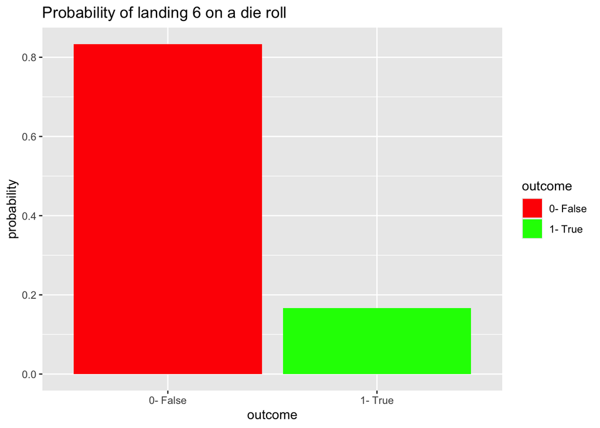

```r
library(ggplot2)
library(dplyr)
probability_of_rolling_6 <- 1/6
data <- data.frame(
  outcome=c("0- False","1- True"),
  probability=c(1-probability_of_rolling_6, probability_of_rolling_6)
)

ggplot(data, aes(x=outcome, y=probability, fill=outcome)) +
  geom_bar(stat = "identity") +
  scale_fill_manual(values = c("red", "green") )+
  labs(title="Probability of landing 6 on a die roll")
```

Running multiple experiments with multiple trials in each experiment, we can see how the distribution would look like. Here we will conduct the experiment using a small number of trials and then a large number of trials. This will show that having a larger trial size better represents all data including the tails. **THINK OF INCREASING THE NUMBER OF TRIALS ALLOWS YOU TO SEE COMPLETE RANGE AND INCREASING THE EXPERIMENT GIVES CLEARER PICTURE DUE TO CENTRAL LIMIT THEORM**.

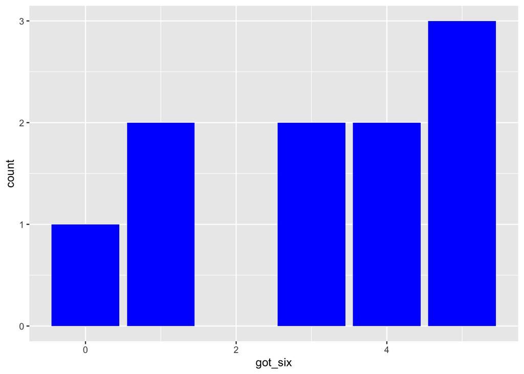

```r
create_binomial_dist<- function(num_of_experiment, num_of_trials, probability) {
  results <- rbinom(num_of_experiment, num_of_trials, probability)
  data <- data.frame(got_six = results)

  ggplot(data, aes(x=got_six)) +
    geom_bar(fill = "blue")
}

create_binomial_dist(10, 20, probability_of_rolling_6)
```

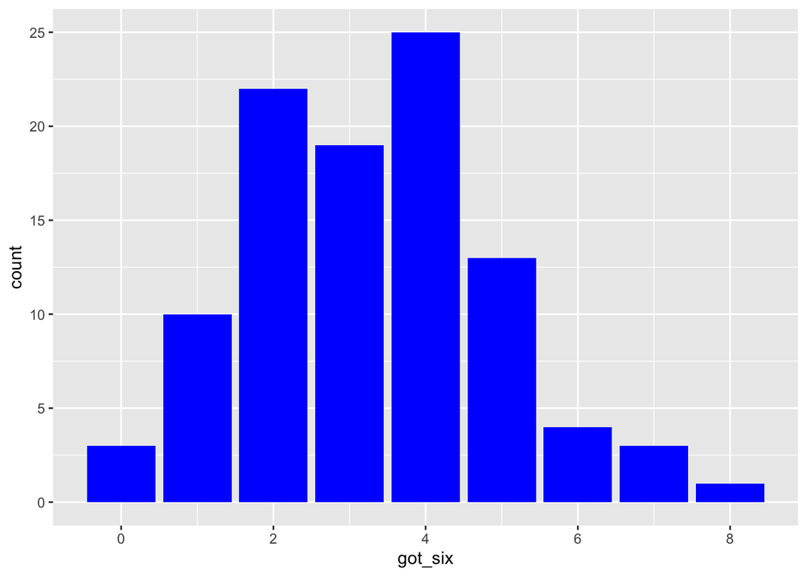

```r
create_binomial_dist(100, 20, probability_of_rolling_6)
```

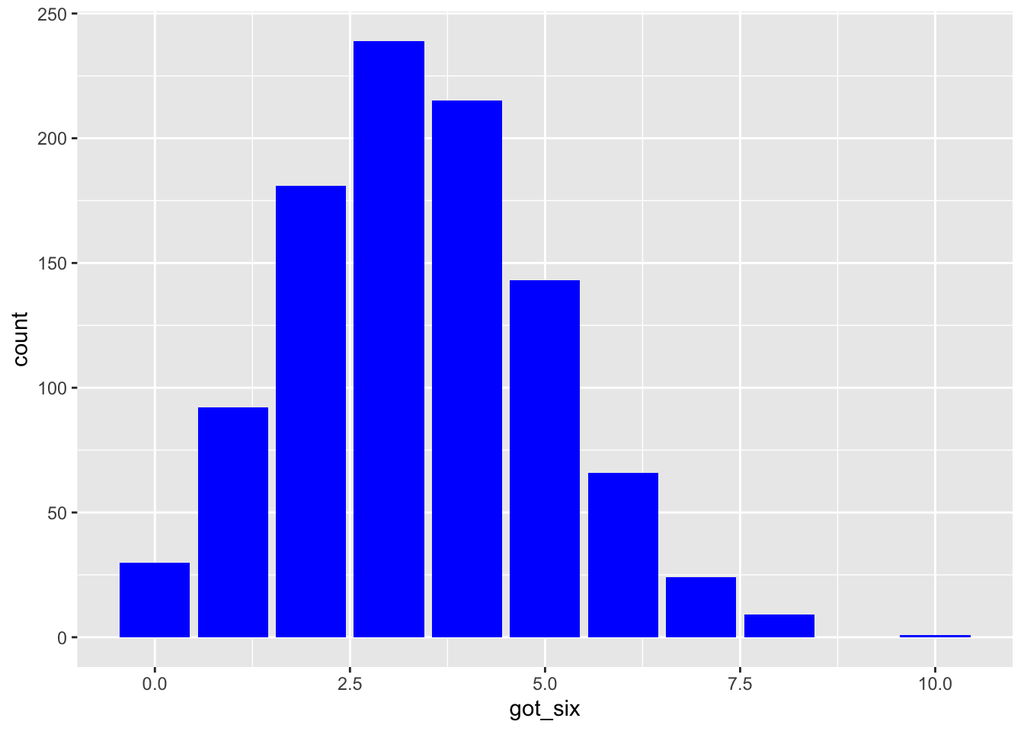

```r
create_binomial_dist(1000, 20, probability_of_rolling_6)
```

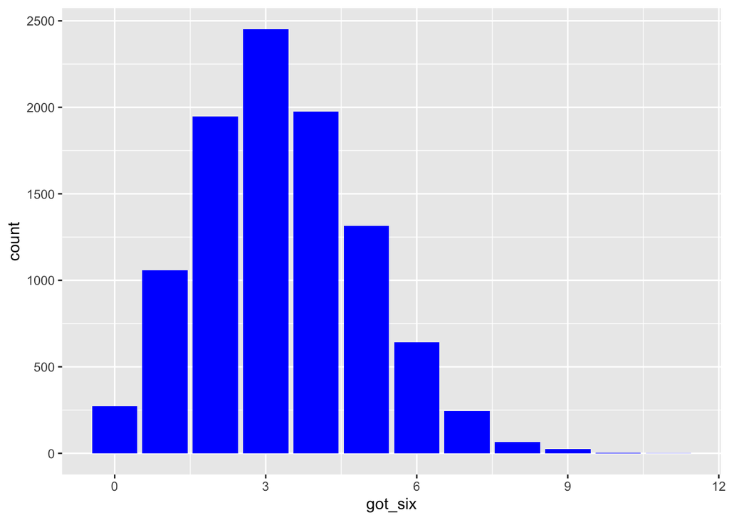

```r
create_binomial_dist(10000, 20, probability_of_rolling_6)
```

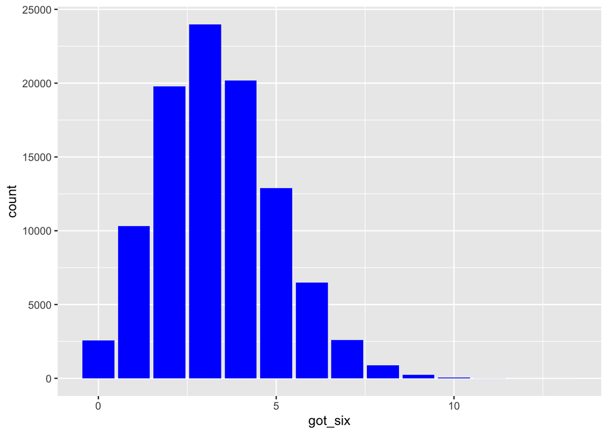

```r
create_binomial_dist(100000, 20, probability_of_rolling_6)
```

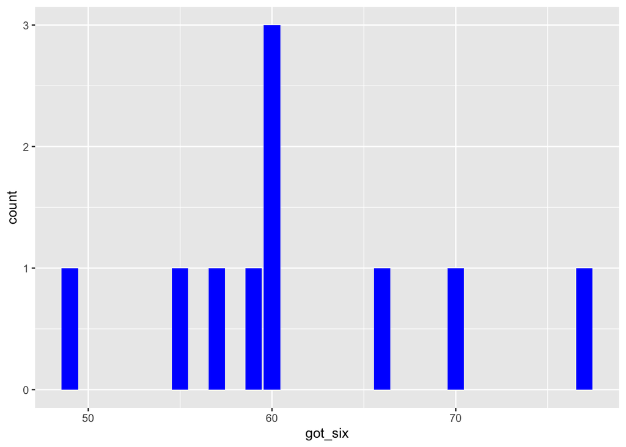

```r
create_binomial_dist(10, 360, probability_of_rolling_6)
```

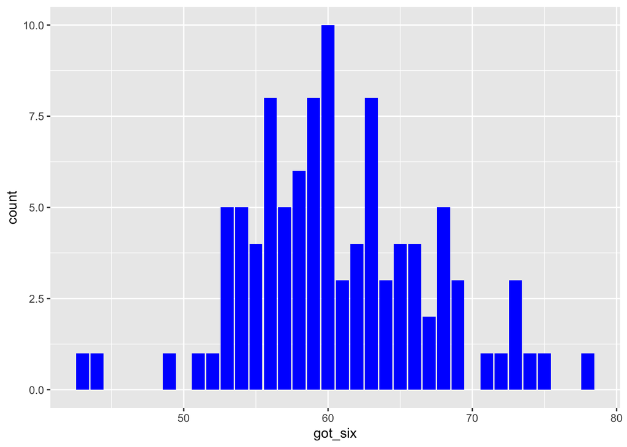

```r
create_binomial_dist(100, 360, probability_of_rolling_6)
```

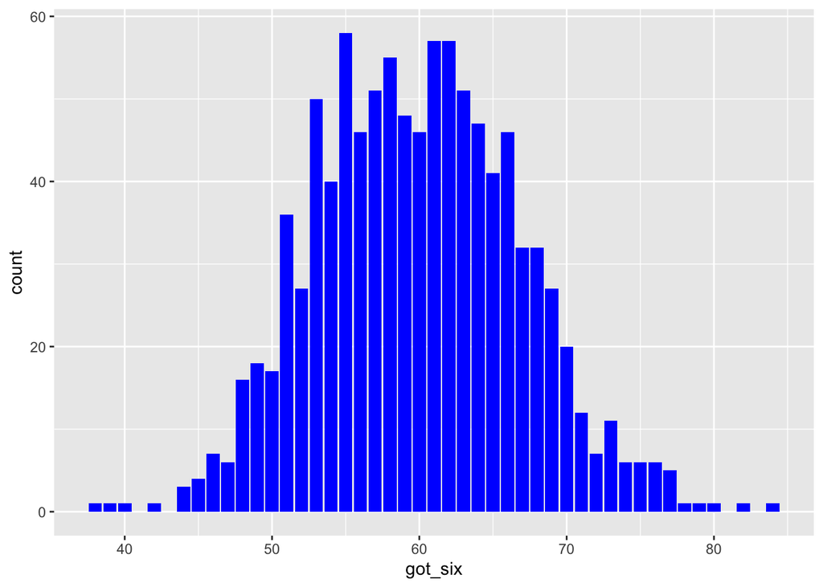

```r
create_binomial_dist(1000, 360, probability_of_rolling_6)
```

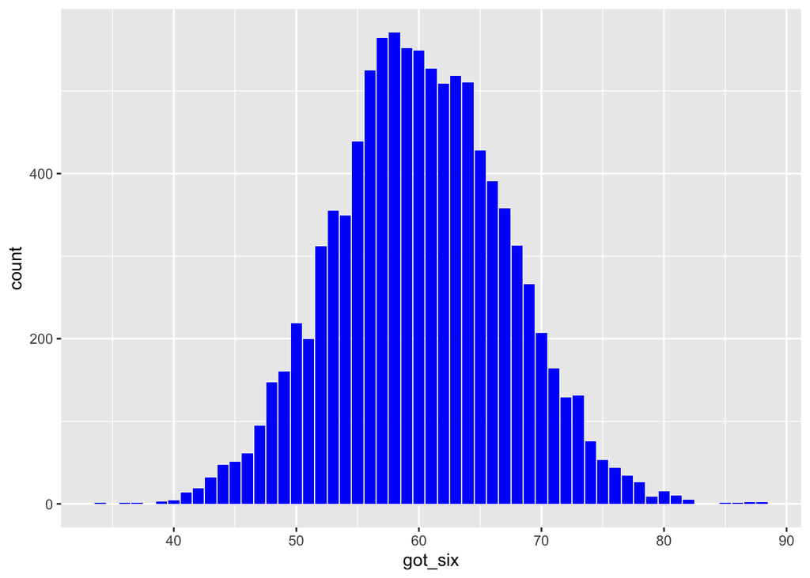

```r
create_binomial_dist(10000, 360, probability_of_rolling_6)
```

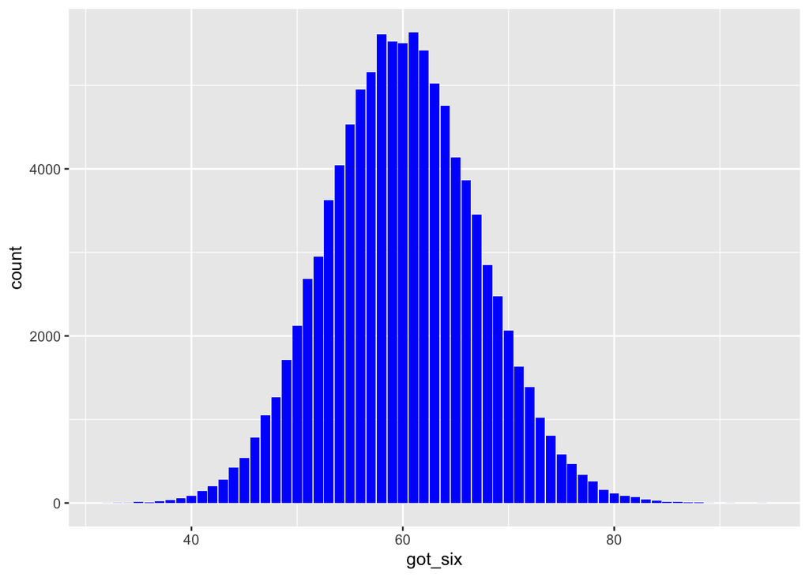

```r
create_binomial_dist(100000, 360, probability_of_rolling_6)
```

#### ANALYSIS

In our experiment, we rolled the die 360 times and got 66 6s, 60 5s, 64 4s, 58 3s, 63 2s, 49 1s. Using binomial formula we get: 360C66 * (1/6)^66 * (5/6)^294

```r
probability_result <- dbinom(66, size = 360, prob = 1/6)
print(probability_result)
```

```
## [1] 0.03820861
```

However this does not give us anything to show that 6 was rolled unfair amount of times. We can either use our Gaussian like distribution to fit our result and find p-value based on z score or just use binomial test. **I will use binomial test**

#### HYPOTHESIS TESTING

Here we can do binomial test to find the p-value with significance level of 5%. We will do two tailed test to find the fairness of the die.

```r
binom.test(x = 66, n = 360, p = 1/6, alternative = "two.sided")
```

```
##
##  Exact binomial test
##
## data:  66 and 360
## number of successes = 66, number of trials = 360, p-value = 0.3961
## alternative hypothesis: true probability of success is not equal to 0.1666667
## 95 percent confidence interval:
##  0.1447213 0.2272455
## sample estimates:
## probability of success
##              0.1833333
```

We see that the p-value is no less than or equal to .05.

Furthermore we do see very little amount of 1s with a value of 49 rolls. However this also gives us p-value more than .05 so nothing odd here either.

```r
binom.test(x = 49, n = 360, p = 1/6, alternative = "two.sided")
```

```
##
##  Exact binomial test
##
## data:  49 and 360
## number of successes = 49, number of trials = 360, p-value = 0.1371
## alternative hypothesis: true probability of success is not equal to 0.1666667
## 95 percent confidence interval:
##  0.1024205 0.1759250
## sample estimates:
## probability of success
##              0.1361111
```

**CONCLUSION: CANNOT DISPROVE NULL HYPOTHESIS**

## MUSIC SHUFFLE (PART 2)

In this experiment, we will try to see if a music shuffle in Spotify will be a fair shuffle with 1/n probability for each outcome. Or will we see certain songs appear more than others.

• We first have a null hypothesis to make claim that each song has equal chance of appearing.

- **Null Hypothesis**: P(each song showing up) = 1/n

• We then have alternative hypothesis which if proven right will contradict our null hypothesis. This will disprove that the shuffle is fair.

- **Alternative Hypothesis**: P(each song showing up) != 1/n

• We have random variable for the experiment.

- **Random variable**: number of times a given song was played

#### EXPLORE DATA

We use Exportify to get an excel sheet of a playlist of 23 songs. The trial size is limited due to the limitation of time. The playlist has some songs that I listen to on regular basis and some songs I do not listen to. There are several repeated artist to see if the shuffling algorithm latches on to similar genre or creator.

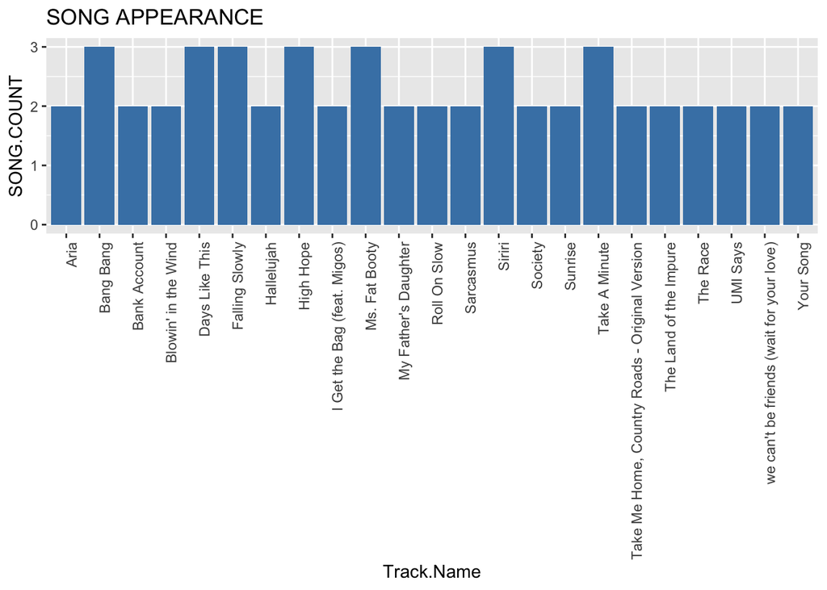

```r
dataframe_of_playlist <- read.csv("Test.csv");
attach(dataframe_of_playlist)

ggplot(dataframe_of_playlist, aes(x = Track.Name, y = SONG.COUNT)) +
  geom_col(fill = "steelblue") +
  labs(title = "SONG APPEARANCE") +
  theme(axis.text.x = element_text(angle = 90, hjust = 1))
```

```r
print(SONG.COUNT)
```

```
##  [1] 2 3 2 3 2 2 2 2 2 2 3 2 2 2 2 2 2 2 3 3 2 3 3
```

#### OBSERVATION

The first run played all song once before moving to repeats. The playlist iterates, it iterates each one randomly but plays all songs before iterating again.

#### TEST

We will do a chi test but the data still isn’t sufficient. However, given that all song iterates at least once, I would be a better idea to stop here.

**We will use CHI Test to be fairness of shuffle**

```r
chisq.test(x = SONG.COUNT, p = rep( 1/length(SONG.COUNT), length(SONG.COUNT)))
```

```
##
##  Chi-squared test for given probabilities
##
## data:  SONG.COUNT
## X-squared = 2.1132, df = 22, p-value = 1
```

#### CONCLUSION

We are not able to disprove the null hypothesis. However, I am not certain if the shuffle algorithm randomizes or creates weight as a song is not play so every song gets played atleast once. NOTE: This experiment in incomplete. We would need to look at how shuffle works if used on playlist that is used more often. The playlist in this experiment was freshly created.